# Survival Analysis

Dominika Nowak

# 1 - Wstęp

Do przeprowadzenia analizy historii zdarzeń wykorzystano zbiór danych *gbsg* z pakietu Survival. Zestaw danych zawiera dokumentację z badania przeprowadzonego w latach 1984-1989 przez niemiecką grupę badawczą nad rakiem piersi na 720 pacjentkach z rakiem piersi z przerzutami do węzłów chłonnych. W zbiorze danych zostały zachowane dane 686 pacjentek z pełnym zbiorem informacji. Rak piersi jest najczęściej występującym nowotworem złośliwym u kobiet. Powstaje z komórek gruczołu piersiowego, który rozwija się miejscowo w piersi oraz daje przerzuty do węzłów chłonnych i narządów wewnętrznych (np. płuc, wątroby, kości i mózgu). Celem badania jest określenie, które zmienne ze zbioru danych najbardziej wpływają na przeżywalność kobiet lub nawrót choroby kobiet z rakiem piersi.

## 1.1 - W zbiorze danych występują następujące zmienne:

- *pid* - identyfikator pacjentki
- *age* - wiek badanej pacjentki wyznaczony w latach
- *meno* - stan menopauzy (0 = przed menopauzą, 1 = po menopauzie)
- *size* - wielkość guza [mm]; w pierwszym stadium raka piersi guz ma średnicę nie większą niż 50mm, w drugim stadium guz osiąga wielkość między 20mm, a 50mm, kolejne stadia to guz powyżej 50mm oraz inne czynniki
- *grade* - stopień guza; I stopień – nowotwór we wczesnej fazie rozwoju, II stopień – nowotwór średnio-zaawansowany, III stopień – nowotwór zaawansowany
- *nodes* - liczba węzłów chłonnych z przerzutami; jest to jeden z głównych czynników określających stopień zaawansowania raka
- *pgr* - receptory progesteronowe (fmol/l)
- *er* - receptory estrogenowe (fmol/l)

receptory estrogenowe (ER) i progesteronowe (PGR) to specyficzne białka obecne w komórkach określonych tkanek organizmu. Ich funkcją jest wiązanie estrogenów i progesteronu, żeńskich hormonów płciowych obecnych we krwi, które stymulują wzrost komórek i ich podziały; badanie na ich obecność wykonuje się w celu ustalenia rodzaju leczenia farmakologicznego i prognozowania w nowotworach sutka

- *hormon* - terapia hormonalna, 0 = nie, 1 = tak; hormonoterapia jest jedną z metod leczenia raka piersi. Warunkiem włączenia takiego leczenia jest obecność receptorów hormonalnych na powierzchni komórek nowotworowych, co stwierdzane jest na podstawie badania wycinka guza. Jest to leczenie mniej toksyczne, a także zmniejsza prawdopodobieństwo nawrotów choroby
- *rfstime* - czas przeżycia bez nawrotów; dni do pierwszego nawrotu, zgonu lub ostatniej obserwacji
- *status* - 0 = żyje bez nawrotu, 1 = nawrót lub śmierć
- *cens* - wskaźnik cenzurowania; 0 = ocenzurowane, 1 = zdarzenie

## 1.2 - Niezbędne biblioteki do realizacji projektu:

- *survival*
- *survminer*
- *survMisc*
- *gtools*
- *MASS*
- *mfp*
- *splines*
- *gridExtra*
- *ggplot2*
- *psych*
- *CoxR2*
- *dplyr*

```r
#install.packages('survival')
library(survival)
#install.packages('survminer')
library(survminer)
#install.packages('survMisc')
library(survMisc)
#install.packages('gtools')
library(gtools)
#install.packages('MASS')
library(MASS)
#install.packages('mfp')
library(mfp)
#install.packages('splines')
library(splines)
#install.packages('gridExtra')
library(gridExtra)
#install.packages('ggplot2')
library(ggplot2)
#install.packages('psych')
library(psych)
#install.packages("CoxR2")
library(CoxR2)
#install.packages("dplyr")
library(dplyr)
```

# 2 - Wczytanie i prezentacja danych

Poniżej przedstawiono 10 pierwszych i ostatnich rekordów ze zbioru danych. Występują w nim zarówno zmienne ilościowe jak i jakościowe, jednak te drugie zostały zapisane w formie liczbowej 1/0 (stan menopauzy, czy jest prowadzona terapia hormonalna oraz czy pacjentka żyje bez nawrotu). W badanym zbiorze nie występują braki danych.

```r
data(gbsg)
dane<-gbsg
dane$cens <- (gbsg$status==1)*1
NA_count <- colSums(is.na(dane))
NA_count
```

```
##     pid     age    meno    size   grade   nodes     pgr      er  hormon rfstime
##       0       0       0       0       0       0       0       0       0       0
##  status    cens
##       0       0
```

```r
head(dane,10)
```

```
##     pid age meno size grade nodes pgr er hormon rfstime status cens
## 1   132  49    0   18     2     2   0  0      0    1838      0    0
## 2  1575  55    1   20     3    16   0  0      0     403      1    1
## 3  1140  56    1   40     3     3   0  0      0    1603      0    0
## 4   769  45    0   25     3     1   0  4      0     177      0    0
## 5   130  65    1   30     2     5   0 36      1    1855      0    0
## 6  1642  48    0   52     2    11   0  0      0     842      1    1
## 7   475  48    0   21     3     8   0  0      0     293      1    1
## 8   973  37    0   20     2     9   0  0      1      42      0    0
## 9   569  67    1   20     2     1   0  0      1     564      1    1
## 10 1180  45    0   30     2     1   0  0      0    1093      1    1
```

```r
tail(dane,10)
```

```
##      pid age meno size grade nodes  pgr   er hormon rfstime status cens
## 677 1715  59    1   24     2     1  860  413      0     553      0    0
## 678  383  65    1   20     1     2  912  606      0     991      1    1
## 679 1065  65    1   17     1     1  935  200      0     967      0    0
## 680  326  43    0   20     2     3  980   45      0    1499      0    0
## 681 1247  67    1   27     2     4 1118  753      1    1222      0    0
## 682  586  51    0   30     3     2 1152   38      1    1760      0    0
## 683 1273  64    1   26     2     2 1356 1144      1    1152      0    0
## 684 1525  57    1   35     3     1 1490  209      1    1342      0    0
## 685  736  44    0   21     2     3 1600   70      0     629      0    0
## 686  894  80    1    7     2     7 2380  972      1     758      0    0
```

## 2.1 - Identyfikacja i eliminacja wartości skrajnych

W celu poprawy jakości danych (wartości odstające mogą zaburzać estymację/redykcję/klasyfikację modelu) przeprowadzono identyfikację oraz następnie wyelimionowanie ze zbioru danych wartości skrajnych. Pod uwagę zostały wzięte tylko zmienne ilościowe.

```r
quartiles <- quantile(dane$age, probs=c(.2, .8), na.rm = FALSE)
IQR <- IQR(dane$age)

Lower <- quartiles[1] - 1.5*IQR
Upper <- quartiles[2] + 1.5*IQR

dane2 <- subset(dane, dane$age > Lower & dane$age < Upper)
```

```r
quartiles <- quantile(dane2$size, probs=c(.2, .8), na.rm = FALSE)
IQR <- IQR(dane2$size)

Lower <- quartiles[1] - 1.5*IQR
Upper <- quartiles[2] + 1.5*IQR
dane <- subset(dane2, dane2$size > Lower & dane2$size < Upper)
```

```r
quartiles <- quantile(dane$nodes, probs=c(.2, .8), na.rm = FALSE)
IQR <- IQR(dane$nodes)

Lower <- quartiles[1] - 1.5*IQR
Upper <- quartiles[2] + 1.5*IQR
dane3 <- subset(dane, dane$nodes > Lower & dane$nodes < Upper)
```

```r
quartiles <- quantile(dane3$pgr, probs=c(.2, .8), na.rm = FALSE)
IQR <- IQR(dane3$pgr)

Lower <- quartiles[1] - 1.5*IQR
Upper <- quartiles[2] + 1.5*IQR
dane4 <- subset(dane3, dane3$pgr > Lower & dane3$pgr < Upper)
```

```r
quartiles <- quantile(dane4$er, probs=c(.2, .8), na.rm = FALSE)
IQR <- IQR(dane4$er)

Lower <- quartiles[1] - 1.5*IQR
Upper <- quartiles[2] + 1.5*IQR
dane <- subset(dane4, dane4$er > Lower & dane4$er < Upper)
```

## 2.2 - Statystyki opisowe zmiennych z oczyszczonego zbioru danych

```r
dane$meno <- as.factor(dane$meno)
dane$grade <- as.factor(dane$grade)
dane$hormon<- as.factor(dane$hormon)
dane$status <- as.factor(dane$status)
dane$cens <- as.factor(dane$cens)
summary(dane)
```

```
##       pid              age       meno         size       grade
##  Min.   :   1.0   Min.   :25.0   0:240   Min.   : 3.00   1: 59
##  1st Qu.: 554.2   1st Qu.:45.0   1:280   1st Qu.:20.00   2:336
##  Median :1013.5   Median :51.0           Median :25.00   3:125
##  Mean   : 951.8   Mean   :51.8           Mean   :27.23
##  3rd Qu.:1336.0   3rd Qu.:60.0           3rd Qu.:35.00
##  Max.   :1819.0   Max.   :79.0           Max.   :58.00
##      nodes             pgr              er         hormon     rfstime
##  Min.   : 1.000   Min.   :  0.0   Min.   :  0.00   0:343   Min.   :   8.0
##  1st Qu.: 1.000   1st Qu.:  5.0   1st Qu.:  5.00   1:177   1st Qu.: 566.8
##  Median : 3.000   Median : 25.0   Median : 25.00           Median :1102.5
##  Mean   : 3.948   Mean   : 63.2   Mean   : 50.02           Mean   :1143.9
##  3rd Qu.: 6.000   3rd Qu.: 92.0   3rd Qu.: 77.00           3rd Qu.:1717.0
##  Max.   :14.000   Max.   :356.0   Max.   :257.00           Max.   :2659.0
##  status  cens
##  0:297   0:297
##  1:223   1:223
##
##
##
##
```

## 2.3 - Graficzna prezentacja zmiennych ilościowych

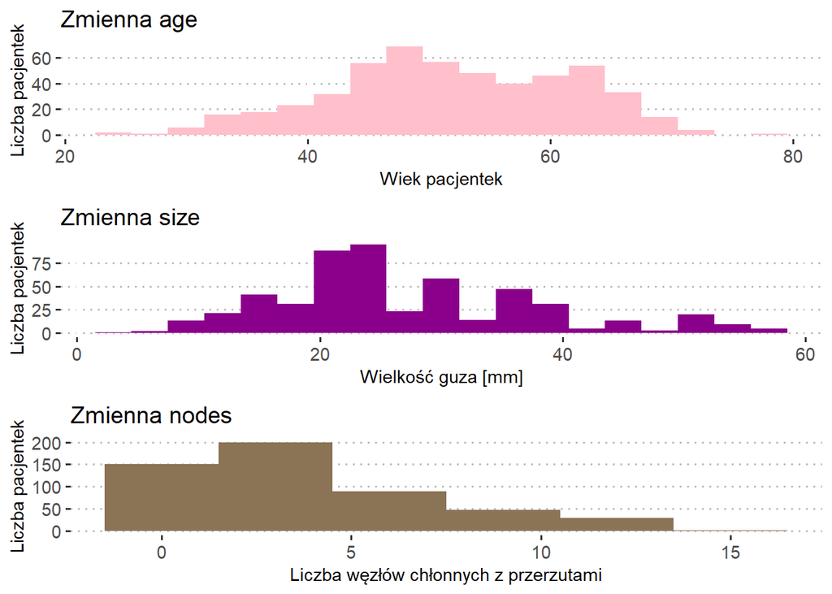

```r
grid.arrange(ggplot(data = dane, aes(x = age)) + geom_histogram(binwidth = 3, fill="pink") + theme_pubclean() +
  labs(y = "Liczba pacjentek") + labs(x = "Wiek pacjentek") +  ggtitle('Zmienna age') +
  theme(axis.title.y = element_text(size=11),
        axis.text.y = element_text(size=11),
        axis.title.x = element_text(size=11),
        axis.text.x = element_text(size=11)),

ggplot(data = dane, aes(x = size)) + geom_histogram(binwidth = 3, fill="darkmagenta") + theme_pubclean() +
  labs(y = "Liczba pacjentek") + labs(x = "Wielkość guza [mm]") + ggtitle('Zmienna size') +
  theme(axis.title.y = element_text(size=11),
        axis.text.y = element_text(size=11),
        axis.title.x = element_text(size=11),
        axis.text.x = element_text(size=11)),

ggplot(data = dane, aes(x = nodes)) + geom_histogram(binwidth = 3, fill="burlywood4") + theme_pubclean() +
  labs(y = "Liczba pacjentek") + labs(x = "Liczba węzłów chłonnych z przerzutami") + ggtitle('Zmienna nodes') +
  theme(axis.title.y = element_text(size=11),
        axis.text.y = element_text(size=11),
        axis.title.x = element_text(size=11),
        axis.text.x = element_text(size=11)) )
```

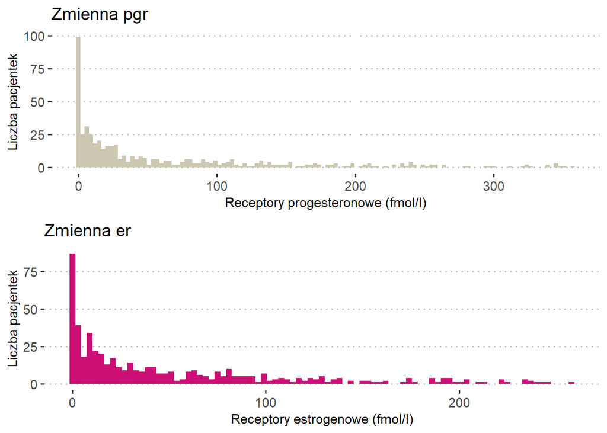

```r
grid.arrange(ggplot(data = dane, aes(x = pgr)) + geom_histogram(binwidth = 3, fill="cornsilk3") + theme_pubclean() +
  labs(y = "Liczba pacjentek") + labs(x = "Receptory progesteronowe (fmol/l)") + ggtitle('Zmienna pgr') +
  theme(axis.title.y = element_text(size=11),
        axis.text.y = element_text(size=11),
        axis.title.x = element_text(size=11),
        axis.text.x = element_text(size=11)),

ggplot(data = dane, aes(x = er)) + geom_histogram(binwidth = 3, fill="deeppink3") + theme_pubclean() +
  labs(y = "Liczba pacjentek") + labs(x = "Receptory estrogenowe (fmol/l)") + ggtitle('Zmienna er') +
  theme(axis.title.y = element_text(size=11),
        axis.text.y = element_text(size=11),
        axis.title.x = element_text(size=11),
        axis.text.x = element_text(size=11)))
```

## 2.4 - Graficzna prezentacja danych zmiennych jakościowych

**Przedstawienie zmiennych meno i grade**

Liczba kobiet z menopauzą (*280*) jest nieznacznie większa od pacjentek przed menopauzą (*240*). Jeśli chodzi o stopień zaawansowania guza to znaczna większość pacjentek (*336*) jest w drugim stopniu zaawansowania (nowotwór średnio zaawansowany). W pierwszym stopniu zaawansowania znajduje się *59* kobiet, a w trzecim stopniu *125* pacjentek.

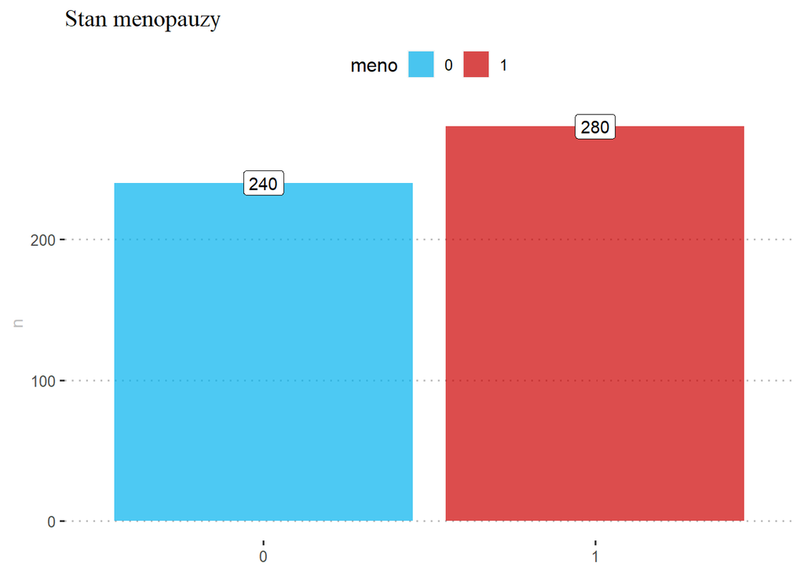

```r
dane %>%
  count(meno) %>%
  ggplot() + geom_col(aes(x = meno, y = n, fill = meno), alpha = 0.7)+ geom_label(aes(x = meno, y = n, label = n)) + scale_fill_manual(values = c("deepskyblue2","red3")) +
  theme_pubclean() +
  ggtitle('Stan menopauzy') +
  theme(axis.title.y = element_text(color="grey", size=11),
        axis.title.x=element_blank(),
        plot.title = element_text(color="black", size=15, family="serif"))
```

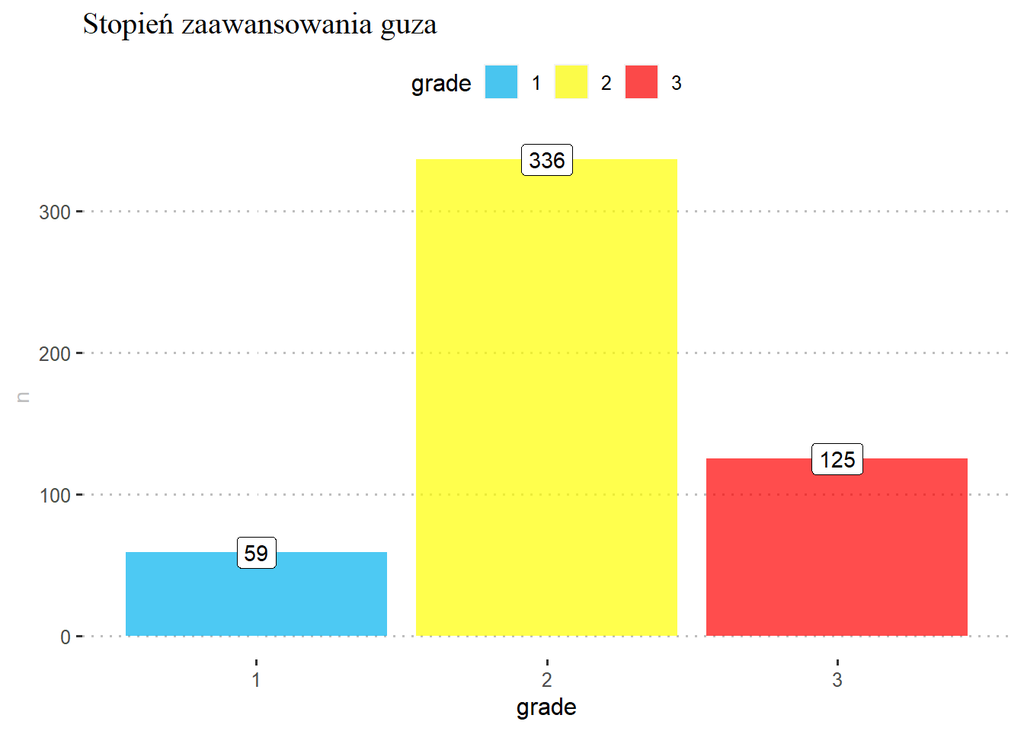

```r
dane %>%
  count(grade) %>%
  ggplot() + geom_col(aes(x = grade, y = n, fill = grade), alpha = 0.7)+ geom_label(aes(x = grade, y = n, label = n)) + scale_fill_manual(values = c("deepskyblue2","yellow","red")) +
  theme_pubclean() +
  ggtitle('Stopień zaawansowania guza') +
  theme(axis.title.y = element_text(color="grey", size=11),
        plot.title = element_text(color="black", size=15, family="serif"))
```

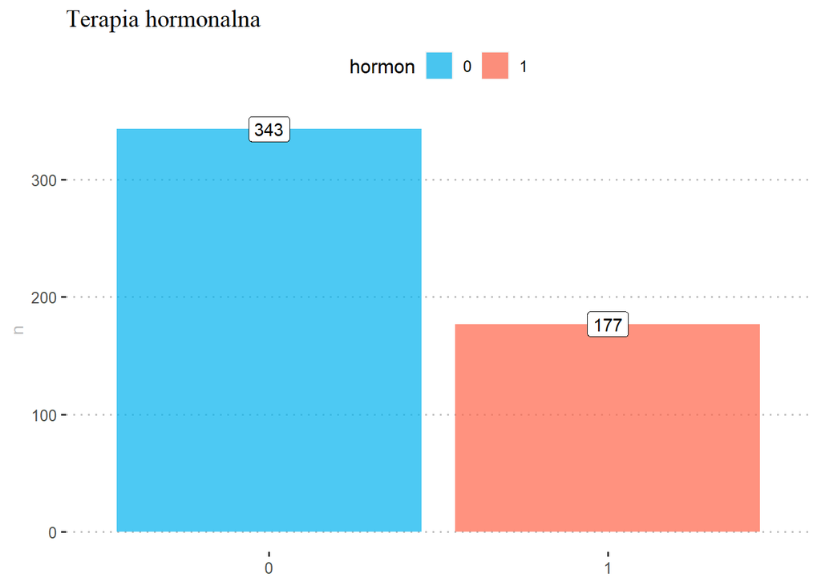

```r
dane %>%
  count(hormon) %>%
  ggplot() + geom_col(aes(x = hormon, y = n, fill = hormon), alpha = 0.7)+ geom_label(aes(x = hormon, y = n, label = n)) + scale_fill_manual(values = c("deepskyblue2","tomato")) +
  theme_pubclean() +
  ggtitle('Terapia hormonalna') +
  theme(axis.title.y = element_text(color="grey", size=11),
        axis.title.x=element_blank(),
        plot.title = element_text(color="black", size=15, family="serif"))
```

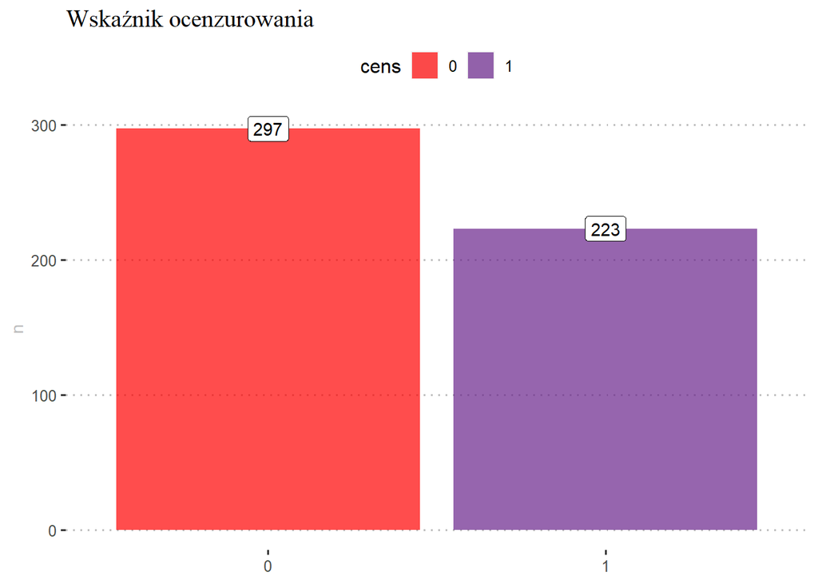

```r
dane %>%
  count(cens) %>%
  ggplot() + geom_col(aes(x = cens, y = n, fill = cens), alpha = 0.7)+ geom_label(aes(x = cens, y = n, label = n)) + scale_fill_manual(values = c("red","darkorchid4")) +
  theme_pubclean() +
  ggtitle('Wskaźnik ocenzurowania') +
  theme(axis.title.y = element_text(color="grey", size=11),
        axis.title.x=element_blank(),
        plot.title = element_text(color="black", size=15, family="serif"))
```

## 2.5 - Rozkład zmiennej rfstime z podziałem według zmiennej cens

Rozkłady dla jednostek cenzurowanych w porównaniu do tych u których wsytąpiło zdarzenie różnią się. U jednostek cenzurowanych można zauważyć skośność lewostronną, natomiast rozkład dla jednostek u których cens=1 występuje skośność prawostronna.

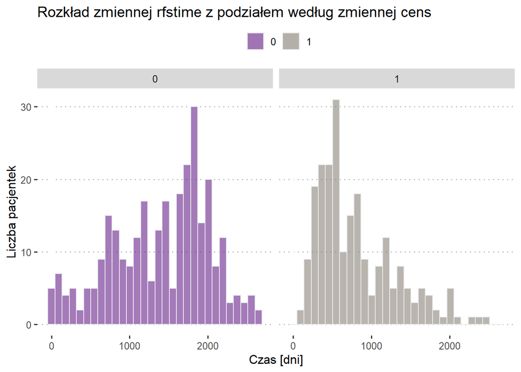

```r
dane %>%
  ggplot( aes(x=rfstime, fill=cens)) +  facet_grid(~cens) +
    geom_histogram( color="#e9ecef", alpha=0.6, position = 'identity') +
    scale_fill_manual(values=c("darkorchid4", "antiquewhite4")) +
    theme_pubclean() + labs(y = "Liczba pacjentek") + labs(x = "Czas [dni]") +
    labs(fill="") + ggtitle('Rozkład zmiennej rfstime z podziałem według zmiennej cens')
```

## 2.6 - Wykresy pudełkowe dla wybranych par zmiennych

- Dla wszystkich stopniów zaawansowania guza średni wiek pacjentek jest podobny.

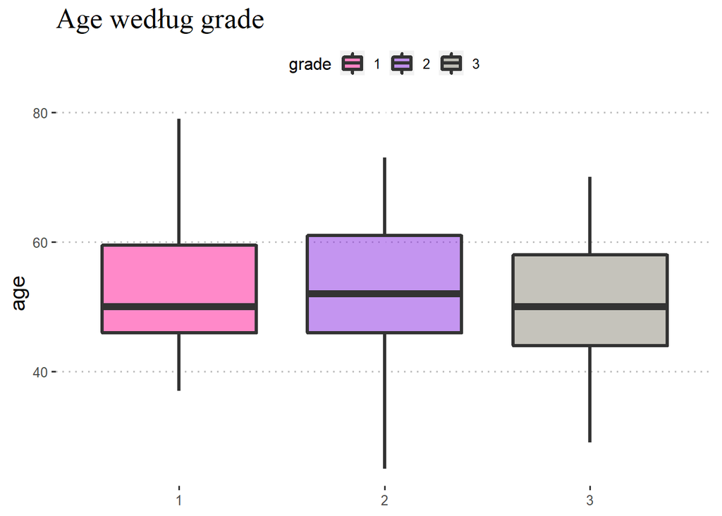

```r
ggplot(dane, aes(x=grade, y = age, fill=grade)) + geom_boxplot(size=1.2, alpha=0.5) +
  scale_fill_manual(values = c("deeppink", "blueviolet","cornsilk4")) + theme_pubclean() +
  ggtitle("Age według grade") +
  theme(axis.title.y = element_text(color="black", size=15),
        axis.title.x=element_blank(),
        plot.title = element_text(color="black", size=20, family="serif")) +
  labs(y = "age")
```

- Terapię hormonalną stosują przeważnie starsze pacjentki.

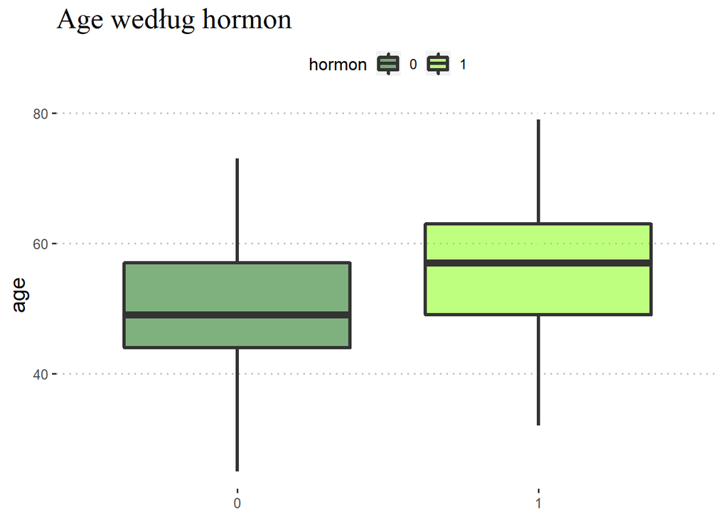

```r
ggplot(dane, aes(x=hormon, y = age, fill=hormon)) + geom_boxplot(size=1.2, alpha=0.5) +
  scale_fill_manual(values = c("darkgreen","chartreuse")) + theme_pubclean() +
  ggtitle("Age według hormon") +
    theme(axis.title.y = element_text(color="black", size=15),
        axis.title.x=element_blank(),
        plot.title = element_text(color="black", size=20, family="serif")) +
  labs(y = "age")
```

- Wraz z wyższym stopniem zaawansowania nowotworu wzrasta wielkość guza wyrażona w milimetrach.

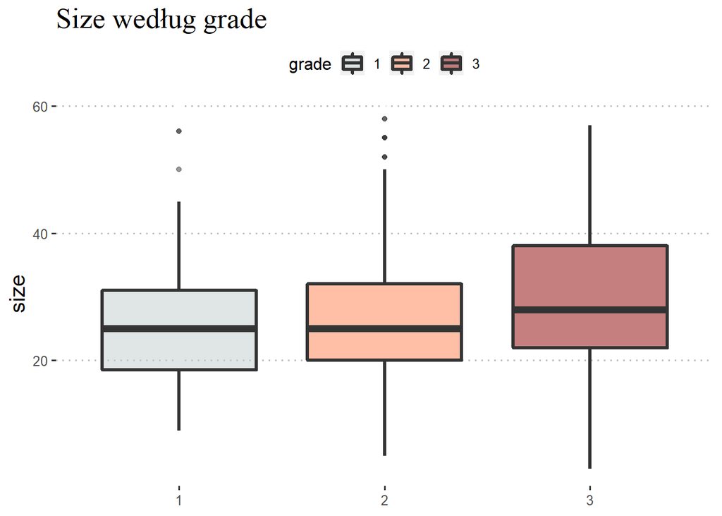

```r
ggplot(dane, aes(x=grade, y = size, fill=grade)) + geom_boxplot(size=1.2, alpha=0.5) +
  scale_fill_manual(values = c("azure3", "coral","darkred")) + theme_pubclean() +
  ggtitle("Size według grade") +
    theme(axis.title.y = element_text(color="black", size=15),
        axis.title.x=element_blank(),
        plot.title = element_text(color="black", size=20, family="serif")) +
  labs(y = "size")
```

- Wraz ze wzrostem zaawansowania nowotworu wzrasta liczba węzłów chłonnych z przerzutami. Wszystkie z ze stopniów zaawansowania guza mają stosunkowo niskie wartości - dla stopnia I - średnia jest na poziomie 3, natomiast dla stopnia II i III wynosi 4.

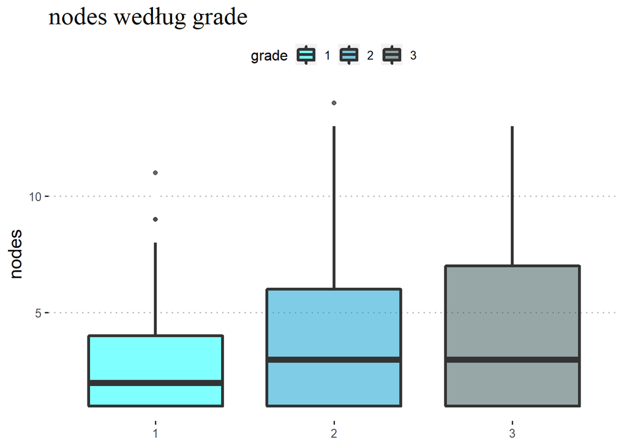

```r
ggplot(dane, aes(x=grade, y = nodes, fill=grade)) + geom_boxplot(size=1.2, alpha=0.5) +
  scale_fill_manual(values = c("cyan", "deepskyblue3","darkslategray")) + theme_pubclean() +
  ggtitle("nodes według grade") +
    theme(axis.title.y = element_text(color="black", size=15),
        axis.title.x=element_blank(),
        plot.title = element_text(color="black", size=20, family="serif")) +
  labs(y = "nodes")
```

- Wraz ze wzrostem zaawansowania nowotworu maleje liczba receptorów progesteronowych. Dla I stopnia guza średnia utrzymuje się na poziomie 120 fmol/l, natomiast dla stopnia zaawansowania II - 67 fmol/l, a dla III stopnia - zaledwie 24 fmol/l.

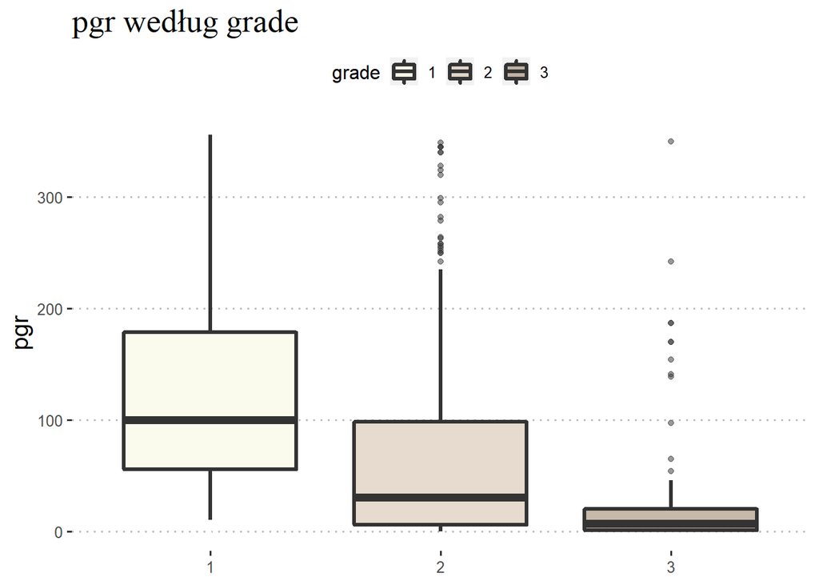

```r
ggplot(dane, aes(x=grade, y = pgr, fill=grade)) + geom_boxplot(size=1.2, alpha=0.5) +
  scale_fill_manual(values = c("beige","bisque3","burlywood4")) + theme_pubclean() +
  ggtitle("pgr według grade") +
   theme(axis.title.y = element_text(color="black", size=15),
        axis.title.x=element_blank(),
        plot.title = element_text(color="black", size=20, family="serif")) +
  labs(y = "pgr")
```

- Wraz ze wzrostem zaawansowania nowotworu maleje liczba receptorów estrogenowych. Dla I stopnia guza średnia utrzymuje się na poziomie 80 fmol/l, natomiast dla stopnia zaawansowania II - 53 fmol/l, a dla III stopnia - zaledwie 26 fmol/l.

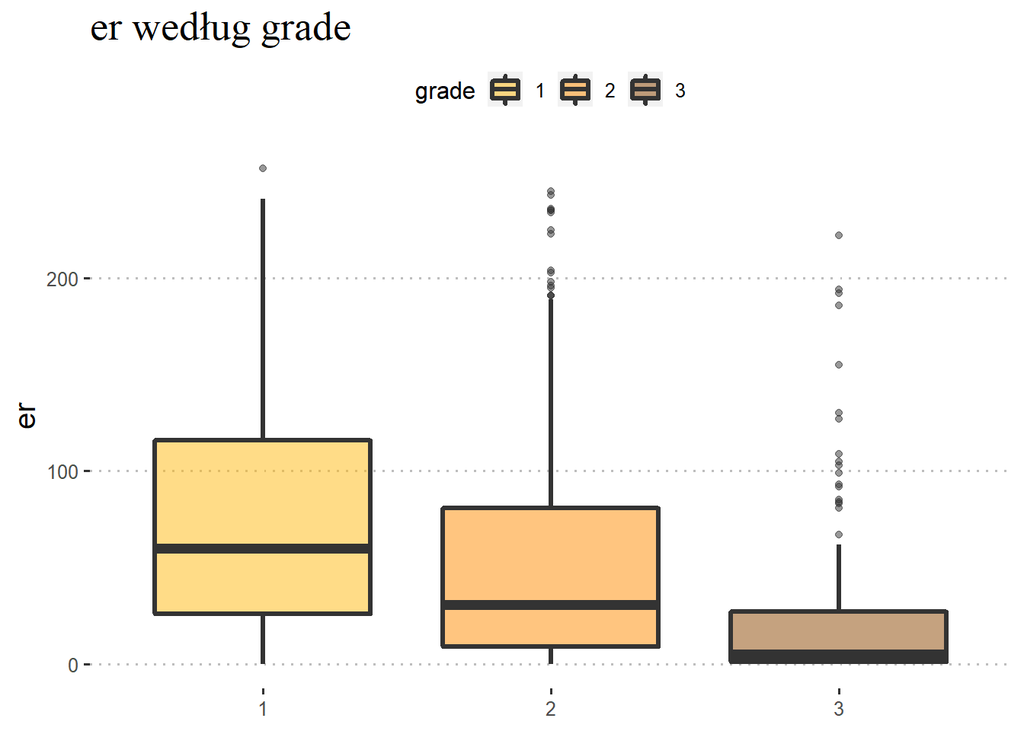

```r
ggplot(dane, aes(x=grade, y = er, fill=grade)) + geom_boxplot(size=1.2, alpha=0.5) +
  scale_fill_manual(values = c("darkgoldenrod1","darkorange","darkorange4")) + theme_pubclean() +
  ggtitle("er według grade") +
   theme(axis.title.y = element_text(color="black", size=15),
        axis.title.x=element_blank(),
        plot.title = element_text(color="black", size=20, family="serif")) +
  labs(y = "er")
```

- Średni czas do wystąpienia zdarzenia w zależności od stopnia zaawansowania guza prezentuje się następująco: stopień I - 1371 dni, stopień II - 1164 dni oraz stopień III - 983 dni.

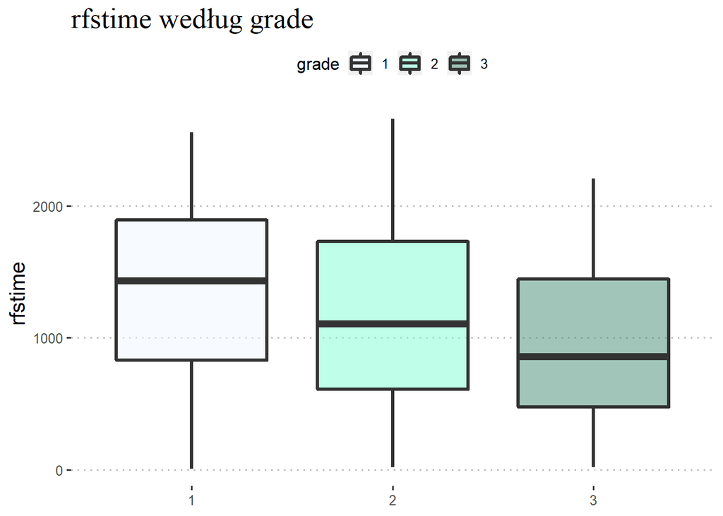

```r
ggplot(dane, aes(x=grade, y = rfstime, fill=grade)) + geom_boxplot(size=1.2, alpha=0.5) +
  scale_fill_manual(values = c("aliceblue","aquamarine","aquamarine4")) + theme_pubclean() +
  ggtitle("rfstime według grade") +
   theme(axis.title.y = element_text(color="black", size=15),
        axis.title.x=element_blank(),
        plot.title = element_text(color="black", size=20, family="serif")) +
  labs(y = "rfstime")
```

## 2.7 - Korelogram zmiennych ilościowych

Analizując poniższy korelogram można zauważyć, że korelacje pomiędzy zmiennymi przyjmują małe wartości. Najsilniejsza korelacja dodatnia występuje pomiędzy parą zmiennych pgr i er (*0,36*), natomiast najsilniejsza korelacja ujemna występuje pomiędzy zmiennymi pgr i nodes (*-0,16*). Najniższe korrelacje z oizistałymi zmiennymi tworzy zmienna size.

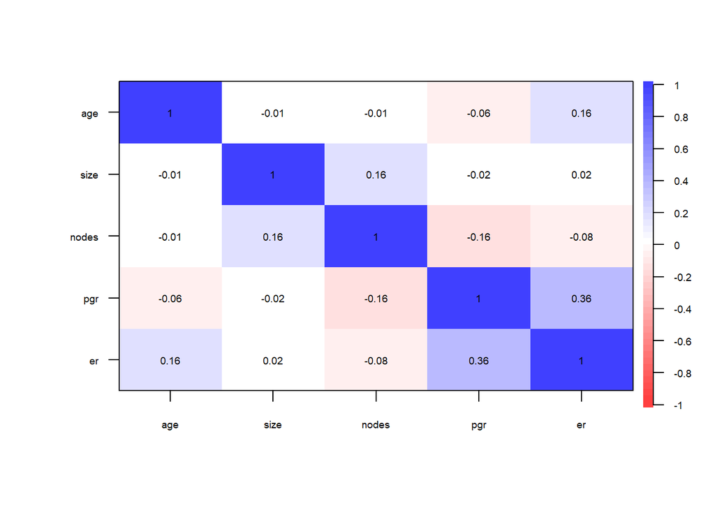

```r
kr <- dane[,c(2,4,6,7,8)]
k=cor(kr)
corPlot(k, cex = 0.6, cex.axis=0.6,cex.lab=2)
```

# 3 - Funkcja przeżycia i skumulowanego hazardu

## 3.1 - Porównanie estymatorów Kaplana - Meiera i Nelsona - Aelena

Na poniższym wykresie zobrazowano funkcje przeżycia dla wszystkich jednostek ze zredukowanego zbioru danych przy użyciu estymatora Kaplana - Meiera oraz Nelsona - Aelena, dla 2 rodzajów przedziału ufności - liniowego i logarytmicznego.

- linia zielona - estymator Kaplana - Meiera z liniowym przedziałem ufności
- linia czerwona - estymator Kaplana - Meiera z logarytmicznym przedziałem ufności
- linia niebieska - estymator Nelsona - Aelena z liniowym przedziałem ufności
- linia pomarańczowa- estymator Nelsona - Aelena z logarytmicznym przedziałem ufności

```r
dane$cens=(dane$status==1)*1
Surv(dane$rfstime,dane$cens)
```

[output not shown]

[output cut: 29 more lines]

```r
dane$cens <- as.numeric(dane$cens)
```

Na wykresie można zauważyć brak istotnych różnic pomiędzy estymatorami oraz ich przedziałami ufności.

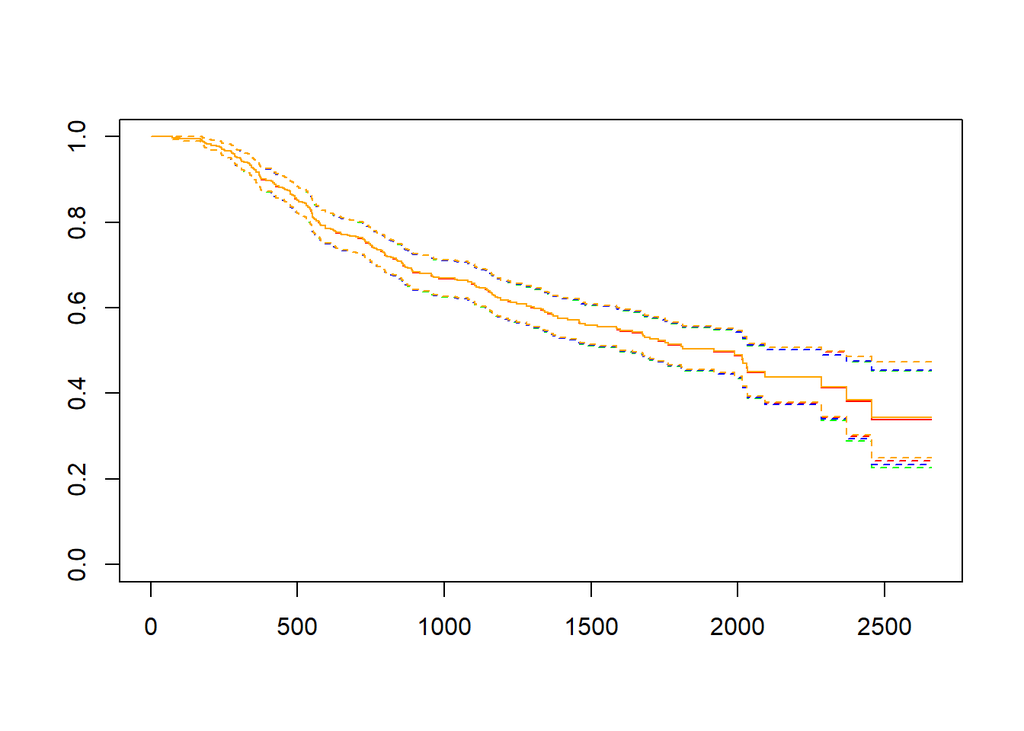

```r
km1 <- survfit(Surv(rfstime, cens) ~ 1, conf.type="plain", data=dane) # estymator KM
plot(km1,col="green")
km2<-survfit(Surv(rfstime,cens)~1,conf.type="log", data=dane) # estymator KM
lines(km2, col="red")

nels1<-survfit(Surv(rfstime,cens) ~ 1, conf.type ="plain", type="fleming-harrington",data=dane) # estymator NA
lines(nels1,col="blue")
nels2<-survfit(Surv(rfstime,cens) ~ 1, conf.type ="log", type="fleming-harrington",data=dane) # estymator NA
lines(nels2,col="orange")
```

### 3.1.1 - Statystyki funkcji przeżycia z użyciem estymatora Kaplana - Meiera i Nelsona - Aalena

```r
summary(km1)$table
```

```
##    records      n.max    n.start     events      rmean  se(rmean)     median
##  520.00000  520.00000  520.00000  223.00000 1681.20639   47.32881 1918.00000
##    0.95LCL    0.95UCL
## 1601.00000 2286.00000
```

```r
cat("\n")
```

```r
summary(km2)$table
```

```
##    records      n.max    n.start     events      rmean  se(rmean)     median
##  520.00000  520.00000  520.00000  223.00000 1681.20639   47.32881 1918.00000
##    0.95LCL    0.95UCL
## 1601.00000 2286.00000
```

```r
cat("\n")
```

```r
summary(nels1)$table
```

```
##    records      n.max    n.start     events      rmean  se(rmean)     median
##  520.00000  520.00000  520.00000  223.00000 1683.72733   47.50609 1918.00000
##    0.95LCL    0.95UCL
## 1601.00000 2286.00000
```

```r
cat("\n")
```

```r
summary(nels2)$table
```

```
##    records      n.max    n.start     events      rmean  se(rmean)     median
##  520.00000  520.00000  520.00000  223.00000 1683.72733   47.50609 1918.00000
##    0.95LCL    0.95UCL
## 1641.00000 2286.00000
```

## 3.2 - Rozkłady czasu trwania dla zmiennych

```r
dane$age_cat=quantcut(dane$age,q=4)
dane$size_cat=quantcut(dane$size,q=4)
dane$nodes_cat=quantcut(dane$nodes,q=4)
dane$pgr_cat=quantcut(dane$pgr,q=4)
dane$er_cat=quantcut(dane$er,q=4)
```

### 3.2.1 - Wykresy funkcji czasu trwania dla zmiennych meno, grade i hormon oraz testy krzywych przeżycia

**Biorąc pod uwagę zmienną *meno* prawdopodobieństwo przeżycia jest bardzo zbliżone w obu grupach (przed i po menopauzie), jednak po 2000 dniu prawdopodobieństwo wzrasta dla kobiet przed menopauzą. Mediana czasu przeżycia dla kobiet przed menopazuą wynosi 2034 dni, natomiast dla kobiet po menopauzie 1763 dni. Test Peto Peto (p-value = 1) i Log-Rank (p-value = 0.68) także wykazał, że zmienna meno nie jest istotnym predyktorem (na poziomie istotności alfa=0,05).**

```r
menort <- survfit(Surv(rfstime, cens) ~ meno, data = dane)
summary(menort)$table
```

```
##        records n.max n.start events    rmean se(rmean) median 0.95LCL 0.95UCL
## meno=0     240   240     240     97 1722.948  70.72896   2034    1463      NA
## meno=1     280   280     280    126 1656.258  62.15020   1763    1481    2372
```

```r
Meno_t=survfit(Surv(rfstime,cens) ~ meno, data=dane, conf.type ="none", type="fleming-harrington") # estymator NA
test1=survdiff(Surv(rfstime,cens)~meno, data=dane, rho=1) # test Peto i Peto
test1
```

```
## Call:
## survdiff(formula = Surv(rfstime, cens) ~ meno, data = dane, rho = 1)
##
##          N Observed Expected (O-E)^2/E (O-E)^2/V
## meno=0 240     76.5     76.2  0.000692   0.00158
## meno=1 280     93.9     94.1  0.000561   0.00158
##
##  Chisq= 0  on 1 degrees of freedom, p= 1
```

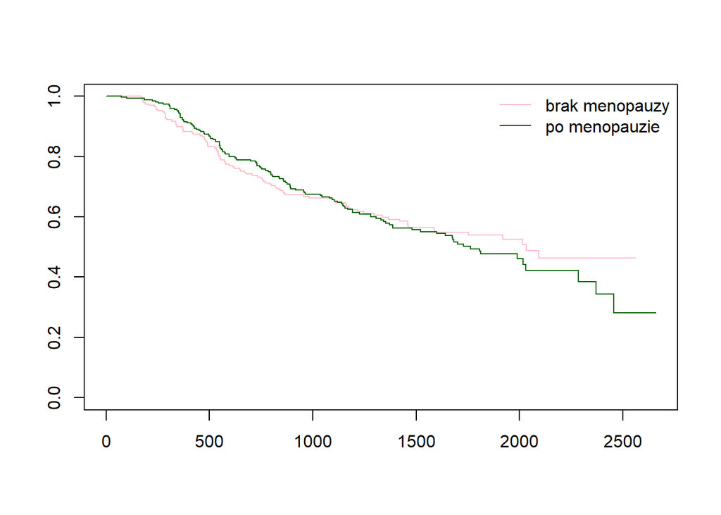

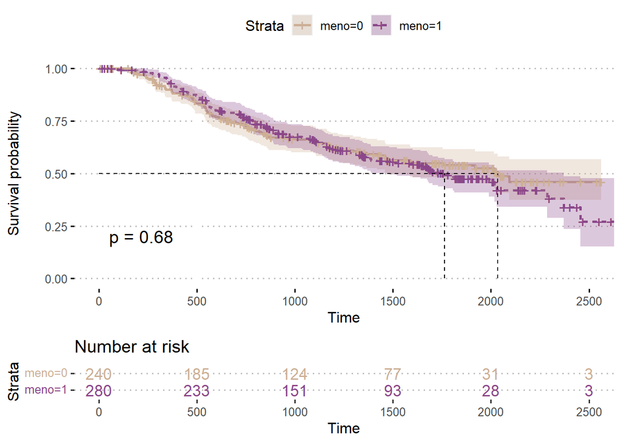

```r
plot(Meno_t,col=c("pink","darkgreen"))
legend("topright",c("brak menopauzy","po menopauzie"),lty=1,col=c("pink","darkgreen"),bty="n")

ggsurvplot(survfit(Surv(rfstime, cens) ~ meno, data = dane),
           pval = TRUE, conf.int = TRUE,
           risk.table = TRUE,
           risk.table.col = "strata",
           linetype = "strata",
           surv.median.line = "hv",
           ggtheme = theme_pubclean(),
           palette = c("peachpuff3","orchid4"))
```

**Dla grup pacjentek podzielonych względem zmiennej *grade*, test Log-Rank wskazał na istotne różnice między grupami (p-value = 0.00068). Prawdopodobieństwo przeżycia jest największe dla kobiet z nowotowetem w pierwszym stopniu rozwoju (wczesna faza), natomiast dla kobiet z nowotworem drugiego i trzeciego stopnia na zbliżonym poziomie. Test Peto Peto także wykazał, że zmienna grade jest istotnym predyktorem (na poziomie istotności alfa=0,05).**

```r
gradert <- survfit(Surv(rfstime, cens) ~ grade, data = dane)
summary(gradert)$table
```

```
##         records n.max n.start events    rmean se(rmean) median 0.95LCL 0.95UCL
## grade=1      59    59      59     12 2207.926 113.07811     NA      NA      NA
## grade=2     336   336     336    154 1645.276  56.73391   1753    1463    2093
## grade=3     125   125     125     57 1574.421 105.75991   1587    1108      NA
```

```r
grade_t=survfit(Surv(rfstime,cens) ~ grade, data=dane, conf.type ="none", type="fleming-harrington") # estymator NA
test2=survdiff(Surv(rfstime,cens)~grade, data=dane, rho=1) # test Peto i Peto
test2
```

```
## Call:
## survdiff(formula = Surv(rfstime, cens) ~ grade, data = dane,
##     rho = 1)
##
##           N Observed Expected (O-E)^2/E (O-E)^2/V
## grade=1  59     8.09     22.6    9.3480    13.925
## grade=2 336   115.20    111.9    0.0948     0.349
## grade=3 125    47.04     35.7    3.5648     5.624
##
##  Chisq= 16.7  on 2 degrees of freedom, p= 2e-04
```